# Celtic Seas

##### Figure 9: Habitat 2

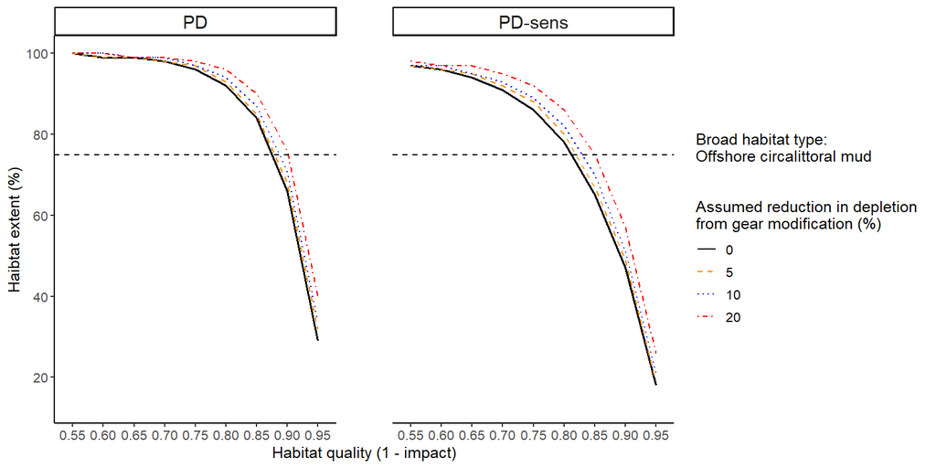

##### Figure 10: Habitat 3

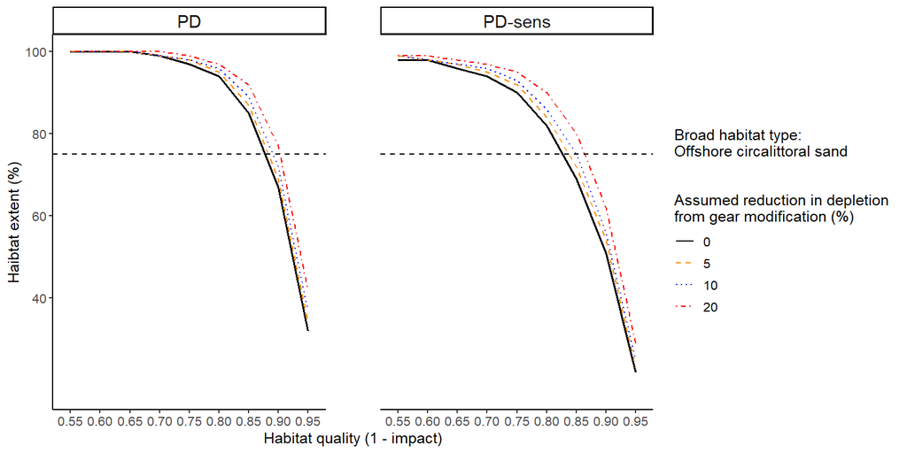

##### Figure 11: Habitat 4

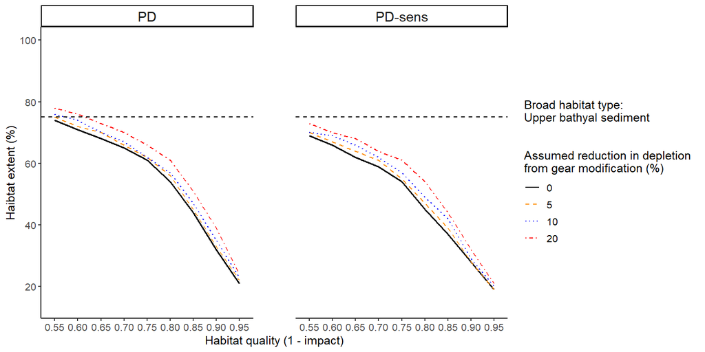

## Essential information

**Content of this advice product**

This interactive document presents information on the distribution, intensity, impact, landings weight, and landings value of mobile bottom-contacting gear (MBCG) fisheries within the Celtic Seas area and the estimated consequences and costs (expressed as loss of landings weight and value) of reducing the relative extent of areas fished with MBCG. The information is from an assessment for the Celtic Seas area for the period 2017‒2022. The six-year period was selected to include the latest available vessel monitoring system (VMS) and logbook data rather than to match a specific Marine Strategy Framework Directive (MSFD) assessment period (EU, 2008). The assessment describes fishing intensity and impact with five pressure indicators and four benthic impact indicators (Table E1).

**Table E1. Pressure and impact indicators, including the spatial scale and period for which indicators are evaluated. C-square refers to a grid cell of dimensions 0.05° latitude × 0.05° longitude. Examples of the “defined area” referred to in the description would be an area within a specified depth range or an area with the same BHT.**

[output not shown]

For each defined assessment area and subdivision, sections of this interactive document provide “summary” information and information on “fishing intensity”, “core fishing grounds”, “fishing by métier”, “impact”, and “scenarios” (Table E2).

**Table E2. Information provided in the tabs for each assessment area.**

Tab

Description

Summary

- Values of pressure indicators I‒1 to I‒5 and impact indicators I‒6a, I‒6b, I‒7a and I‒7b by depth strata (Table 1).
- Maps of swept area ratio, median longevity of benthic fauna, and landings value and weight (Figure 1).
- Estimates of the contribution of small-scale fisheries (MBCG vessels < 12 m overall length) to total fishing effort in kW × days (Table 2).

Fishing intensity

- The extent of broad habitat types, and various estimates of MBCG fishing activity for these habitat types; fisheries landings, value, and intensity (Table 3).
- Temporal variation of pressure indicators I‒1, I‒3, and I‒4 (Figure 2).

Fishing by métier

- Estimates of swept area, landings weight, and landings value for the active métiers (Table 4).

Core fishing grounds

- Spatial stability of core fishing grounds (smallest area responsible for 90% of the landings value) over time (Figure 3).
- Spatial distribution of the stability of core fishing grounds (Figure 4).

Impact

- Spatial distribution of MBCG fisheries impact indicator values (I‒6a) and (I‒6b) (Figure 5).
- Temporal variation of impact indicators I‒6a, I‒6b, I‒7a, and I‒7b (Figure 6).
- Landings weight and value per unit impact for the active métiers (Table 5).
- Métier-specific impacts for the four most extensive broad habitat types (Figure 7).

Scenarios

- A “Footprint reduction” scenario presenting effects of stepwise exclusion of MBCG fisheries in each broad habitat type, in terms of effort reduction (Table 6), landings value (Table 7), and landings weight (Table 8).
- A “Gear modifications” scenario presenting the effects of gear modifications (assumed reduction in the depletion of benthic faunal biomass after a gear pass) on the quality-extent threshold for the four most extensive habitat types (Figures 8‒11).

**Assessment area**

**Figure E1. Map of the assessment area, showing the water depth class distributions (left), and boundaries of the relevant (MSFD) divisions and FAO regions (right).**

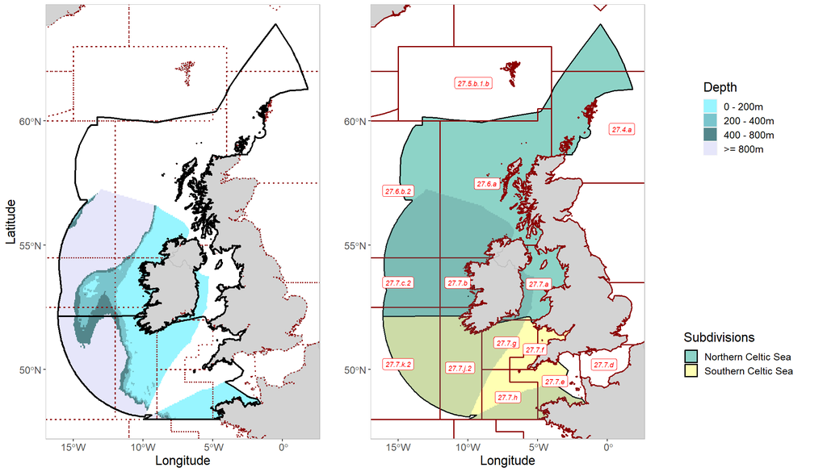

**Limitations of this advice**

Data and analytical limitations are described in the “Limitations” section of the main advice text. This text should be consulted before viewing this interactive document.

**How is fishing intensity evaluated?**

Five pressure indicators were used to describe fishing intensity and distribution resulting from the use of MBCG (Table E1).

These indicators are calculated, for any given area as defined in this document, from estimates of the swept area in each of the c-squares within a defined area of interest. The swept area is calculated as hours fished × average fishing speed × gear width. This requires that VMS location records are linked to logbook data to associate a location and speed with gear code and fishing activity (Data Collection Framework level 4 and 6 respectively). VMS locations are allocated to “fishing” and “not fishing” based on vessel speed and other filters (ICES, 2022). The gear width is estimated based on relationships between average gear widths and average vessel length or engine power (kW; Eigaard et al. 2016; ICES, 2022). The swept-area ratio (SAR) is calculated as the sum of the area swept by a defined set of MBCG in a defined area (usually one c-square) in a defined period (usually one year) divided by the area of the defined area. Therefore, when calculated at the c-square scale, the SAR indicates the theoretical number of times the c-square is swept per year, assuming that the MBCG fishing is evenly distributed over the c-square. For example, a SAR of 2 means that the entire c-square is fished two times over the year, a SAR of 0.5 means that the entire c-square is fished once in two years.

**How is benthic impact evaluated?**

Four indicators were used to describe benthic impacts. These indicators are generated from the assessment methods PD and PD-sens. PD (population dynamics method) is used to estimate the loss of benthic biomass, relative to carrying capacity, from a defined area if the current MBCG fishing intensity continues indefinitely (Pitcher et al., 2017; ICES, 2018; Hiddink et al., 2019; ICES, 2022). PD-sens (population dynamics method for sensitive fauna) is used to estimate the loss of biomass of sensitive benthic fauna (the 10% most long-lived biomass fraction), relative to carrying capacity, from a defined area if the current MBCG fishing intensity continues indefinitely (ICES, 2024). For this advice, PD and PD-sens are estimated at the c-square scale.

PD and PD-sens are estimated from SAR and parameters for depletion (proportional mortality) per pass of a MBCG and the intrinsic rate of increase of biomass of the benthic community (Pitcher et al. 2017). Estimates of depletion were métier-specific and taken from Rijnsdorp et al (2020). The intrinsic rate of increase is estimated from the predicted local distribution of maximum ages in an unimpacted benthic community (Rijnsdorp et al., 2018). When PD-sens rather than PD is calculated, only the 10% most long-lived biomass fraction of this community is used to estimate the intrinsic rate of increase, to address the component of the benthic biomass most sensitive to MBCG.

**How are landings values evaluated?**

VMS location records are linked to logbook data to associate a location with gear code and fishing activity (Data Collection Framework level 4 and 6 respectively), and with landings weight and landings value records. VMS location records are classified as “fishing” and “not fishing” based on vessel speed and other filters (ICES, 2022). Landings weight and value are then allocated to the VMS location records classified as fishing, based on the time interval between location records or an equal split among location records by day, by ICES rectangle or by trip. Total landings weight or value by c-square, in a given time-interval, are calculated as the sum of the allocations to each location record in that c-square.

**References**

Eigaard O. R., Bastardie F., Breen M. l., Dinesen G. E., Laffargue P., Mortensen, J., et al. 2016. Estimating seafloor pressure from trawls and dredges based on gear design and dimensions. ICES Journal of Marine Science 73(1): 27−43 https://doi.org/10.1093/icesjms/fsv099

EU. 2008. Directive 2008/56/EC of the European Parliament and of the Council of 17 June 2008 establishing a framework for community action in the field of marine environmental policy (Marine Strategy Framework Directive) (Text with EEA relevance). Official Journal of the European Union L164, 19−40. http://data.europa.eu/eli/dir/2008/56/oj

Hiddink, J. G., Jennings, S., Sciberras, M., Bolam, S. G., Cambiè, G., McConnaughey, R. A., Mazor, T., et al. 2019 Assessing bottom-trawling impacts based on the longevity of benthic invertebrates. Journal of Applied Ecology, 56: 1075–1083. https://doi.org/10.1111/1365-2664.13278

ICES. 2018. Interim Report of the Working Group on Fisheries Benthic Impact and Trade-offs (WGFBIT), 12–16 November 2018, ICES Headquarters, Copenhagen, Denmark. ICES CM 2018/HAPISG:21. 74 pp.

ICES. 2022. Working Group on Fisheries Benthic Impact and Trade-offs (WGFBIT; outputs from 2021meeting). ICES Scientific Reports. 4:9. 133 pp. http://doi.org/10.17895/ices.pub.10042

Pitcher, C. R., Ellis, N., Jennings, S., Hiddink, J. G., Mazor, T., Kaiser, M. J., Kangas, M. I., et al. 2017. Estimating the sustainability of towed fishing-gear impacts on seabed habitats: a simple quantitative risk assessment method applicable to data-limited fisheries. Methods in Ecology and Evolution. 8: 472–480. https://doi.org/10.1111/2041-210X.12705.

Rijnsdorp, A. D., Bolam, S. G., Garcia, C., Hiddink, J. G., Hintzen, N. T., van Denderen, D. P., and Van Kooten, T. 2018. Estimating sensitivity of seabed habitats to disturbance by bottom trawling based on the longevity of benthic fauna. Ecological Applications, 28: 1302–1312. https://doi.org/10.1002/eap.1731

Rijnsdorp, A. D., Hiddink, J. G., van Denderen, P. D., Hintzen, N. T., Eigaard, O. R., Valanko, S., Bastardie, F., et al. 2020. Different bottom trawl fisheries have a differential impact on the status of the North Sea seafloor habitats. ICES Journal of Marine Science. 77(5): 1772–86. https://doi.org/10.1093/icesjms/fsaa050